# Random effects demo

Kie Zuraw

Wednesday, October 18, 2017

# Introduction and setup

Set random seed, to ensure that we get the same results every time, and load any necessary packages

```r
set.seed(123)

require(lattice) || install.packages("lattice")
```

```
## [1] TRUE
```

```r
require(lattice)

require(lme4) || install.packages("lme4")
```

```
## [1] TRUE
```

```r
require(lme4)
```

# Create fake data

Imaginary and slightly silly data:

- f0 measured throughout the day from multiple speakers
- there’s a linear relationship, with f0 going up throughout the day
- each speaker has their own intercept and slope, added to the basic intercept and slope

Make a data frame with the fake data:

```r
num_of_obs <- 1000 #how much total data I want
my_sd <- 50 #standard deviation for random noise

#make a data frame with speaker, each speaker's deviation from the baseline intercept, and a random sampling of times
f0_by_time <- data.frame(speaker=rep_len(x=c("Anna","Bianca","Carmen","Danielle","Evita"),length.out=num_of_obs), rand_intercept=rep_len(x=c(0,20,-40,40,-20),length.out=num_of_obs), hours_from_noon=runif(n=num_of_obs,min=-6,max=6))

#add f0 as a function of speaker's intercept and time (plus random noise)
f0_by_time$f0 <- (160 + f0_by_time$rand_intercept) + 10*f0_by_time$hours_from_noon + rnorm(n=num_of_obs,mean=0,sd=my_sd)
```

Plot it:

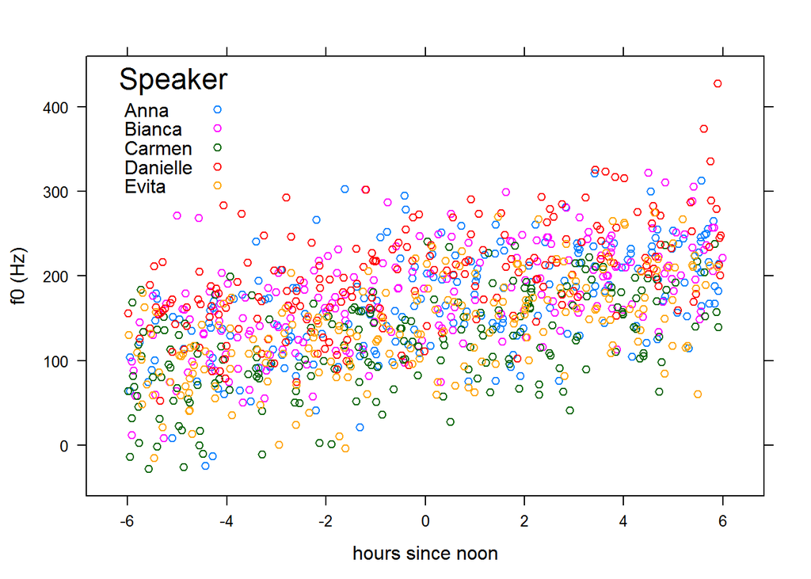

```r
xyplot(f0_by_time$f0 ~ f0_by_time$hours_from_noon, groups=f0_by_time$speaker, auto.key=list(title="Speaker", corner=c(0.05, 1)), xlab="hours since noon", ylab="f0 (Hz)") #auto.key generates the legend
```

# Regression models

Here’s a model with no awareness of speaker (it thinks all the observations are independent):

```r
f0.lm <- lm(f0 ~ hours_from_noon, data=f0_by_time)
summary(f0.lm)
```

```
##
## Call:
## lm(formula = f0 ~ hours_from_noon, data = f0_by_time)
##
## Residuals:
##      Min       1Q   Median       3Q      Max
## -154.757  -36.769   -0.066   39.122  209.572
##
## Coefficients:
##                 Estimate Std. Error t value Pr(>|t|)
## (Intercept)     160.5931     1.7868   89.88   <2e-16 ***
## hours_from_noon   9.8903     0.5182   19.09   <2e-16 ***
## ---
## Signif. codes:  0 '***' 0.001 '**' 0.01 '*' 0.05 '.' 0.1 ' ' 1
##
## Residual standard error: 56.5 on 998 degrees of freedom
## Multiple R-squared:  0.2674, Adjusted R-squared:  0.2667
## F-statistic: 364.3 on 1 and 998 DF,  p-value: < 2.2e-16
```

Here’s a model that treats speaker as a fixed effect. The coefficient for each speaker is as compared to the baseline, Anna, whose intercept is the same as the overall intercept:

```r
f0.lm.speaker_fixed <- lm(f0 ~ hours_from_noon + speaker, data=f0_by_time)
summary(f0.lm.speaker_fixed)
```

```
##
## Call:
## lm(formula = f0 ~ hours_from_noon + speaker, data = f0_by_time)
##
## Residuals:
##      Min       1Q   Median       3Q      Max
## -145.900  -35.080    1.276   33.095  171.840
##
## Coefficients:
##                 Estimate Std. Error t value Pr(>|t|)
## (Intercept)     164.2360     3.5485  46.283  < 2e-16 ***
## hours_from_noon   9.7348     0.4608  21.124  < 2e-16 ***
## speakerBianca    10.7086     5.0149   2.135    0.033 *
## speakerCarmen   -40.5623     5.0231  -8.075 1.94e-15 ***
## speakerDanielle  35.0047     5.0170   6.977 5.49e-12 ***
## speakerEvita    -23.3912     5.0151  -4.664 3.52e-06 ***
## ---
## Signif. codes:  0 '***' 0.001 '**' 0.01 '*' 0.05 '.' 0.1 ' ' 1
##
## Residual standard error: 50.08 on 994 degrees of freedom
## Multiple R-squared:  0.4267, Adjusted R-squared:  0.4239
## F-statistic:   148 on 5 and 994 DF,  p-value: < 2.2e-16
```

And one that treats speaker as a random effect:

```r
f0.lmer.speaker_random <- lmer(f0 ~ hours_from_noon + (1|speaker), data=f0_by_time)
summary(f0.lmer.speaker_random)
```

```
## Linear mixed model fit by REML ['lmerMod']
## Formula: f0 ~ hours_from_noon + (1 | speaker)
##    Data: f0_by_time
##
## REML criterion at convergence: 10677.1
##
## Scaled residuals:
##     Min      1Q  Median      3Q     Max
## -2.9120 -0.6978  0.0209  0.6574  3.4421
##
## Random effects:
##  Groups   Name        Variance Std.Dev.
##  speaker  (Intercept)  853.9   29.22
##  Residual             2508.1   50.08
## Number of obs: 1000, groups:  speaker, 5
##
## Fixed effects:
##                 Estimate Std. Error t value
## (Intercept)     160.5881    13.1643   12.20
## hours_from_noon   9.7371     0.4608   21.13
##
## Correlation of Fixed Effects:
##             (Intr)
## hors_frm_nn 0.001
```

```r
ranef(f0.lmer.speaker_random)
```

```
## $speaker
##          (Intercept)
## Anna        3.594084
## Bianca     14.148923
## Carmen    -36.379264
## Danielle   38.093592
## Evita     -19.457336
```

The numbers look pretty close.

# Adding in speakers with less data

```r
#same procedure as before for making the fake data, just with fewer observations and two new speakers
num_of_obs_small <- 10

small <- data.frame(speaker=rep_len(x=c("Francesca","Gaelle"), length.out=num_of_obs_small), rand_intercept=rep_len(x=c(-100,100),length.out=num_of_obs_small), hours_from_noon=runif(n=num_of_obs_small,min=-6,max=6))

small$f0 <- (160 + small$rand_intercept) + 10*small$hours_from_noon + rnorm(n=num_of_obs_small,mean=0,sd=my_sd)

f0_by_time <- rbind(f0_by_time,small) #add the new data on to the old data frame
```

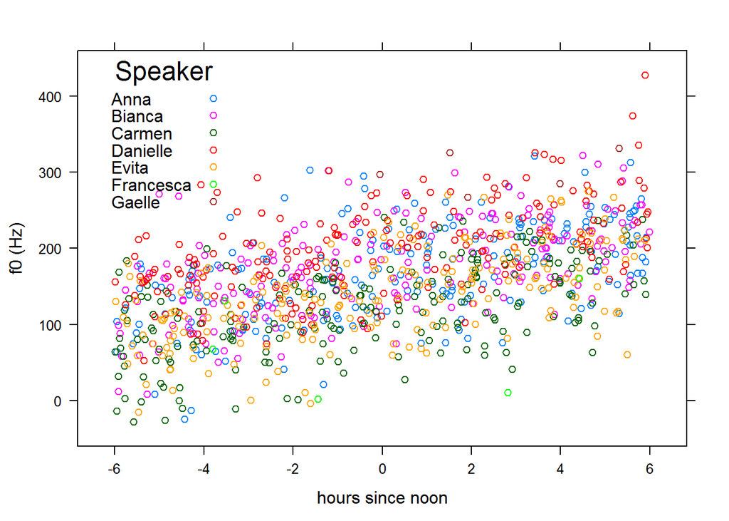

```r
xyplot(f0_by_time$f0 ~ f0_by_time$hours_from_noon, groups=f0_by_time$speaker, auto.key=list(title="Speaker", corner=c(0.05, 1)), xlab="hours since noon", ylab="f0 (Hz)")
```

Let’s compare speaker coefficients as a fixed effect to speaker’s random intercepts.

Again, a model that treats speaker as a fixed effect.

```r
f0.lm.speaker_fixed2 <- lm(f0 ~ hours_from_noon + speaker, data=f0_by_time)
summary(f0.lm.speaker_fixed2)
```

```
##
## Call:
## lm(formula = f0 ~ hours_from_noon + speaker, data = f0_by_time)
##
## Residuals:
##      Min       1Q   Median       3Q      Max
## -146.116  -34.998    1.229   33.165  172.106
##
## Coefficients:
##                  Estimate Std. Error t value Pr(>|t|)
## (Intercept)       164.258      3.553  46.233  < 2e-16 ***
## hours_from_noon     9.691      0.460  21.069  < 2e-16 ***
## speakerBianca      10.684      5.021   2.128 0.033592 *
## speakerCarmen     -40.599      5.029  -8.073 1.96e-15 ***
## speakerDanielle    34.976      5.023   6.963 6.01e-12 ***
## speakerEvita      -23.416      5.021  -4.664 3.53e-06 ***
## speakerFrancesca  -87.068     22.706  -3.835 0.000134 ***
## speakerGaelle     112.711     22.722   4.960 8.26e-07 ***
## ---
## Signif. codes:  0 '***' 0.001 '**' 0.01 '*' 0.05 '.' 0.1 ' ' 1
##
## Residual standard error: 50.14 on 1002 degrees of freedom
## Multiple R-squared:  0.4412, Adjusted R-squared:  0.4373
## F-statistic:   113 on 7 and 1002 DF,  p-value: < 2.2e-16
```

And one that treats speaker as a random effect:

```r
f0.lmer.speaker_random2 <- lmer(f0 ~ hours_from_noon + (1|speaker), data=f0_by_time)
summary(f0.lmer.speaker_random2)
```

```
## Linear mixed model fit by REML ['lmerMod']
## Formula: f0 ~ hours_from_noon + (1 | speaker)
##    Data: f0_by_time
##
## REML criterion at convergence: 10796.3
##
## Scaled residuals:
##     Min      1Q  Median      3Q     Max
## -2.9116 -0.6985  0.0243  0.6603  3.4320
##
## Random effects:
##  Groups   Name        Variance Std.Dev.
##  speaker  (Intercept) 3255     57.05
##  Residual             2515     50.15
## Number of obs: 1010, groups:  speaker, 7
##
## Fixed effects:
##                 Estimate Std. Error t value
## (Intercept)      164.838     22.020   7.486
## hours_from_noon    9.709      0.460  21.108
##
## Correlation of Fixed Effects:
##             (Intr)
## hors_frm_nn -0.005
```

```r
ranef(f0.lmer.speaker_random2)
```

```
## $speaker
##           (Intercept)
## Anna       -0.5866296
## Bianca     10.0662803
## Carmen    -41.0142812
## Danielle   34.2667318
## Evita     -23.9025714
## Francesca -75.9094692
## Gaelle     97.0799392
```

These two new speakers’ fitted numbers are closer to zero when treated as random intercepts than when treated as fixed-effect coefficients. Let’s plot that:

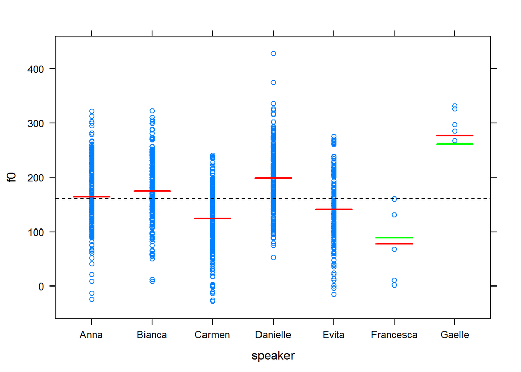

```r
xyplot(f0 ~ speaker, data=f0_by_time, panel=function(x,y) {
  panel.xyplot(x,y)
  panel.abline(h=mean(f0_by_time$f0), lty=2) #dotted line at the overall mean (should be about 160)
  panel.segments(x0=c(1:7)-0.3,y0=f0.lmer.speaker_random2@beta[1]+ranef(f0.lmer.speaker_random2)$speaker[,1],x1=c(1:7)+0.3,y1=f0.lmer.speaker_random2@beta[1]+ranef(f0.lmer.speaker_random2)$speaker[,1], col="green", lwd=2) #a short green line at each speaker's random intercept (plus the overall intercept), given in terms of starting and ending x and y coordinates on the plot
  panel.segments(x0=c(1:7)-0.3,y0=f0.lm.speaker_fixed2$coefficients[1]+c(0,f0.lm.speaker_fixed2$coefficients[3:9]),x1=c(1:7)+0.3,y1=f0.lm.speaker_fixed2$coefficients[1]+c(0,f0.lm.speaker_fixed2$coefficients[3:9]),col="red",lwd=2) # a short red line at each speaker's coefficient in the speaker-as-fixed-effect model (plus the overall intercept)
  })
```

Red lines show intercept+coefficients in fixed-effects model. Green lines show intercept+random intercepts in mixed-effects model (not visible for first five speakers, because red line is on top of green line)

So how come the numbers are not exactly the same for Francesca and Gaelle? Why are they closer to the overall intercept?

- the coefficients for fixed effects are estimated using least squares/maximum likelihood (maybe with some “regularization”, or penalty on making coefficients too big without lots of evidence)
- the random intercepts are estimated using “shrinkage”
- each speaker’s personal intercept is a weighted average (i.e., a blend) of the intercept seen in that speaker’s data and the intercept seen in the data overall
- the point is to bias the random intercepts towards the overall intercept
- bias how much, and how exactly (e.g., does it *have* to be using a weighted average)? Bleh, don’t ask me. Or rather, see the documentation for the lme4 package for how lmer() does it.

One of the best tutorials I’ve seen on this is by USC’s Sandrah Eckel: (http://www-hsc.usc.edu/~eckel/talk_CDrandomInterceptFeb2010.pdf). I copied her format for showing the fixed-effects coefficients vs. random intercepts.